# [VHH Project] Pipeline Prototyping

July, 2023

This document is meant to re-build an [Immcantation](https://immcantation.readthedocs.io/) B-cell repertoire analysis, and initially relied completely on documentation from within that framework. Now, we introduce original Alpaca immunization data.

### Data Sources (Per TH, June 13 2023)

- Pre-immune repertoires are the ones that **do not** include a `G` in their file name.
- Files prefixed with `A` reference the alpaca Alexander.
- Files prefixed with `L` reference the alpaca Lara.
- Files prefixed with `PD` reference phage display libraries.
- The files in the `antigen` folders are just the nucleotide sequences that were used to immunize the alpacas.

```
# Alexander
 [1] "A2A_S1_L001_R1_001.fastq"
 [2] "A2A_S1_L001_R2_001.fastq"
 [3] "A2G1_S6_L001_R1_001.fastq"
 [4] "A2G1_S6_L001_R2_001.fastq"
 [5] "A2G2_S12_L001_R1_001.fastq"
 [6] "A2G2_S12_L001_R2_001.fastq"

# Lara
 [8] "L2A_S2_L001_R1_001.fastq"
 [9] "L2A_S2_L001_R2_001.fastq"
[10] "L2G1_S7_L001_R1_001.fastq"
[11] "L2G1_S7_L001_R2_001.fastq"
[12] "L2G2_S13_L001_R1_001.fastq"
[13] "L2G2_S13_L001_R2_001.fastq"
```

### Objectives:

Refactor and write documentation to generalize for future use

- Part 1: (BASH) Raw Read Assembly (pRESTO)
- Part 2: (BASH) Change-O - Repertoire Clonal Assignment Toolkit
- Part 3: (R) Spectral Clustering-Based Method for Identifying B Cell Clones (Scoper)
- Part 4: (BASH) Reconstruct Germlines and Build Phylogenetic Trees
- Part 5: (R) Create an alpaca SHM Model

# Part 1) pRESTO Prototype Workflow

Note that this document relies completely on Illumina MiSeq 2x250 BCR mRNA [example workflow](https://presto.readthedocs.io/en/stable/workflows/Greiff2014_Workflow.html) from pRESTO (The REpertoire Sequencing TOolkit).

### Data Sources

Focuses on data from: Greiff, V. et al. “Quantitative assessment of the robustness of next-generation sequencing of antibody variable gene repertoires from immunized mice.” *BMC Immunol.* (2014)

### Overview

Here, we’re going to review each step required to translate raw sequence reads to an annotated repertoir of V(D)J sequences.

Overall, this is divided into:

1. Paired-end assembly
2. Quality control and primer annotation
3. Deduplication and filtering

#### Read Configuration

[figure not shown]

**Schematic of Illumina MiSeq 2x250 stranded paired-end reads without UMI barcodes.**

**Notes (per workflow documentation):**

*Each 250 base-pair read was sequenced from one end of the target cDNA, so that the two reads together cover the entire variable region of the Ig heavy chain.

- The V(D)J reading frame proceeds from the start of read 2 to the start of read 1.
- Read 1 is in the opposite orientation (reverse complement), and contains the C-region primer sequence.
- Both reads begin with a random sequences of 4 nucleotides.

#### FlowChart

[figure not shown]

### Installation and Environment Setup

#### Immcantation

- First, [immcantation v.4.4.0](https://hub.docker.com/r/immcantation/suite) was downloaded via Docker

```
docker pull immcantation/suite:4.4.0
```

- Next, the [SRA Toolkit](https://github.com/ncbi/sra-tools/wiki/01.-Downloading-SRA-Toolkit) was downloaded, and the [installation guide](https://github.com/ncbi/sra-tools/wiki/02.-Installing-SRA-Toolkit) followed.

#### SRA Toolkit

We need the first 25,000 sequences of sample `ERR346600`, which may downloaded using fastq-dump from the [SRA Toolkit](https://github.com/ncbi/sra-tools/wiki/01.-Downloading-SRA-Toolkit).

```
fastq-dump --split-files -X 25000 ERR346600
```

## 1) Paired-end assembly

### align

Each set of paired-ends mate-pairs is first assembled into a full length Ig sequence using the align subcommand of `AssemblePairs.py`:

During assembly we have defined read 2 (V-region) as the head of the sequence (-1) and read 1 as the tail of the sequence (-2). The `--coord` argument defines the format of the sequence header so that `AssemblePairs.py` can properly identify mate-pairs; in this case, we use `--coord illumina` as our headers are in the Illumina format.

**Our Alpaca Command**

Assemble Paired End Reads

```bash
docker run -v /Users/emoseley/VHH/data:/data immcantation/suite:4.4.0 \
  AssemblePairs.py align -1 /data/A2A_S1_L001_R2_001.fastq -2 /data/A2A_S1_L001_R1_001.fastq \
    --coord illumina --rc tail --maxerror 0.1 --outname ALPACA1 --log /data/ALPACA_AP.log
```

#### Output

```
       START> AssemblePairs
     COMMAND> align
       FILE1> A2A_S1_L001_R2_001.fastq
       FILE2> A2A_S1_L001_R1_001.fastq
  COORD_TYPE> illumina
       ALPHA> 1e-05
   MAX_ERROR> 0.1
     MIN_LEN> 8
     MAX_LEN> 1000
SCAN_REVERSE> False
       NPROC> 6

PROGRESS> 19:12:25 |####################| 100% (2,378,908) 135.0 min

OUTPUT> ALPACA1_assemble-pass.fastq
 PAIRS> 2378908
  PASS> 2099952
  FAIL> 278956
   END> AssemblePairs
```

1. `ALPACA1_assemble-pass.fastq`
2. `ALPACA_AP.log`

```r
# Note that the log file is also in FASTQ format, so we need ShortRead from Bioconductor
# BiocManager::install("ShortRead")
library(ShortRead)

tmp <- ShortRead::readFastq("~/VHH/data/ALPACA1_assemble-pass.fastq")
```

#### ParseLog.py

The `ParseLog.py` tool is then used to build a tab-delimited file of results from the `AssemblePairs.py` log file:

```bash
docker run -v /Users/emoseley/VHH/data:/data immcantation/suite:4.4.0 \
  ParseLog.py -l /data/ALPACA_AP.log -f ID LENGTH OVERLAP ERROR PVALUE
```

**Output:**

```
START> ParseLog
 FILE> ALPACA_AP.log

PROGRESS> 21:20:38 (2378908) 1.6 min

 OUTPUT> ALPACA_AP_table.tab
RECORDS> 2378908
   PASS> 2378908
   FAIL> 0
    END> ParseLog
```

1. `ALPACA_AP_table.tab` (tsv)

Which will containing the following columns:

```
Field Description

ID - Sequence name

LENGTH - Length of the assembled sequence

OVERLAP - Length of the overlap between mate-pairs

ERROR - Mismatch rate of the overlapping region

P-VALUE - P-value for the assembly
```

#### Check Log

```r
# Read the tsv file
tmp <- read.csv("~/VHH/data/ALPACA_AP_table.tab", header = T, stringsAsFactors = F, sep = '\t')

# Look at top-most entries
head(tmp)
```

## 2) (Quality Control Step) Filter Sequence

### Removing Low-Quality Reads

Quality control begins with the identification and removal of low-quality reads using the quality subcommand of the `FilterSeq.py` tool. Here, reads with mean [Phred](https://en.wikipedia.org/wiki/Phred_quality_score) quality scores less than 30 (`-q 30`) are removed:

**Our Alpaca Command**

```bash
docker run -v /Users/emoseley/VHH/data:/data immcantation/suite:4.4.0 \
  FilterSeq.py quality -s /data/ALPACA1_assemble-pass.fastq -q 30 --outname ALPACA1 --log /data/ALPACA1_FS.log
```

**Output:**

[output not shown]

1. `ALPACA1_quality-pass.fastq`
2. `ALPACA1_FS.log`

#### ParseLog.py

The `ParseLog.py` tool is then used to build tab-delimited file from the `FilterSeq.py` log:

**Our Alpaca Command**

```bash
docker run -v /Users/emoseley/VHH/data:/data immcantation/suite:4.4.0 \
  ParseLog.py -l /data/ALPACA1_FS.log -f ID QUALITY
```

**Output:**

With the following variables:

```
Field Description

ID - Sequence name

QUALITY - Quality score
```

#### Check Log

```r
# Read the tsv file
tmp <- read.csv("~/VHH/data/ALPACA1_FS_table.tab", header = T, stringsAsFactors = F, sep = '\t')

# Look at top-most entries
head(tmp)
```

### Read annotation and masking of primer regions

When dealing with Ig sequences, it is important to cut or mask the primers, as B cell receptors are subject to somatic hypermutation (the accumulation of point mutations in the DNA) and degenerate primer matches can look like mutations in downstream applications. The `score` subcommand of `MaskPrimers.py` is used to identify and remove the V-segment and C-region PCR primers for both reads:

**Tutorial Command**

```bash
MaskPrimers.py score -s M1_quality-pass.fastq -p Greiff2014_VPrimers.fasta \
    --start 4 --mode mask --pf VPRIMER --outname M1-FWD --log MPV.log

MaskPrimers.py score -s M1-FWD_primers-pass.fastq -p Greiff2014_CPrimers.fasta \
    --start 4 --mode cut --revpr --pf CPRIMER --outname M1-REV --log MPC.log
```

In this data set the authors have added a random sequence of 4 bp to the start of each read before the primer sequence to increase sequence diversity and the reliability of cluster calling on the Illumina platform. As such, both primers begin at position 4 (`--start 4`), but the C-region primer begins 4 bases from the end of the assembled read. The addition of the `--revpr` argument to the second `MaskPrimers.py` step instructs the tool to reverse complement the primer sequences and check the tail of the read.

The two primer regions have also been treated differently. The V-segment primer has been masked (replaced by Ns) using the `--mode mask` argument to preserve the V(D)J length, while the C-region primer has been removed from the sequence using the `--mode cut` argument.

During each iteration of the `MaskPrimers.py` tool an annotation field was added with the name of the primer, with the name of the field specified by the `--pf` argument, such that after both iterations each sequence contains an annotation of the form:

**Our Alpaca Commands (1)**

```bash
docker run -v /Users/emoseley/VHH/data:/data immcantation/suite:4.4.0 \
MaskPrimers.py score -s /data/ALPACA1_quality-pass.fastq -p /data/AlpVHH.fasta --barcode \
      --start 8 --mode cut --pf VPRIMER --outname ALPACA1-FWD --log /data/ALPACA1-FWD-MPV.log \
      --maxerror 0.01
```

**Output (1):**

```
        START> MaskPrimers
      COMMAND> score
     SEQ_FILE> ALPACA1_quality-pass.fastq
  PRIMER_FILE> AlpVHH.fasta
         MODE> cut
    MAX_ERROR> 0.01
    START_POS> 8
   REV_PRIMER> False
      BARCODE> True
BARCODE_FIELD> BARCODE
 PRIMER_FIELD> VPRIMER
        NPROC> 6

PROGRESS> 23:40:34 |####################| 100% (1,746,609) 16.5 min

   OUTPUT> ALPACA1-FWD_primers-pass.fastq
SEQUENCES> 1746609
     PASS> 1408485
     FAIL> 338124
      END> MaskPrimers
```

1. `ALPACA1-FWD_primers-pass.fastq`
2. `ALPACA1-FWD-MPV.log`

**Our Alpaca Commands (2)**

**Note: this says “MPV” but should be “MPC”**

Note that this uses as input the output of the previous `MaskPrimers.score` call.

```bash
docker run -v /Users/emoseley/VHH/data:/data immcantation/suite:4.4.0 \
MaskPrimers.py score -s /data/ALPACA1-FWD_primers-pass.fastq -p /data/AlpVHH.fasta --barcode \
      --start 8 --mode cut --revpr --pf CPRIMER --outname ALPACA1-REV --log /data/ALPACA1-REV-MPV.log \
      --maxerror 0.01
```

**Output (2):**

```
        START> MaskPrimers
      COMMAND> score
     SEQ_FILE> ALPACA1-FWD_primers-pass.fastq
  PRIMER_FILE> AlpVHH.fasta
         MODE> cut
    MAX_ERROR> 0.01
    START_POS> 8
   REV_PRIMER> True
      BARCODE> True
BARCODE_FIELD> BARCODE
 PRIMER_FIELD> CPRIMER
        NPROC> 6

PROGRESS> 00:33:22 |####################| 100% (1,408,485) 16.1 min

   OUTPUT> ALPACA1-REV_primers-pass.fastq
SEQUENCES> 1408485
     PASS> 1320220
     FAIL> 88265
      END> MaskPrimers
```

#### Parse Log Summary

```bash
docker run -v /Users/emoseley/VHH/data:/data immcantation/suite:4.4.0  \
  ParseLog.py -l /data/ALPACA1-FWD-MPV.log /data/ALPACA1-REV-MPC.log -f ID PRIMER ERROR
```

**Output:**

1. `ALPACA1-REV-MPC_table.tab`
2. `ALPACA1-FWD-MPV_table.tab`

Capturing the following annotations:

```
Field Description

ID Sequence name

PRIMER Primer name

ERROR Primer match error rate
```

#### Check Log

```r
# Read the tsv file
tmpV <- read.csv("~/VHH/data/ALPACA1-FWD-MPV_table.tab", header = T, stringsAsFactors = F, sep = '\t')

# Look at top-most entries
head(tmpV)

tmpC <- read.csv("~/VHH/data/ALPACA1-REV-MPC_table.tab", header = T, stringsAsFactors = F, sep = '\t')

head(tmpC)
```

### ParseHeaders

**Our Alpaca Command**

```bash
docker run -v /Users/emoseley/VHH/data:/data immcantation/suite:4.4.0  \
  ParseHeaders.py collapse -s /data/ALPACA1-REV_primers-pass.fastq -f BARCODE --act cat
```

**Output**

```
  START> ParseHeaders
COMMAND> collapse
   FILE> ALPACA1-REV_primers-pass.fastq
ACTIONS> cat
 FIELDS> BARCODE

PROGRESS> 17:04:17 |####################| 100% (1,320,220) 4.8 min

   OUTPUT> ALPACA1-REV_primers-pass_reheader.fastq
SEQUENCES> 1320220
      END> ParseHeaders
```

### Build Consensus Sequences

**Our Alpaca Command**

```bash
docker run -v /Users/emoseley/VHH/data:/data immcantation/suite:4.4.0  \
    BuildConsensus.py -s /data/ALPACA1-REV_primers-pass_reheader.fastq  --pf VPRIMER \
         --maxerror 0.1  -o /data/ALPACA1-BC1.fastq -n 2 --bf BARCODE
```

**Output**

```
           START> BuildConsensus
            FILE> ALPACA1-REV_primers-pass_reheader.fastq
   BARCODE_FIELD> BARCODE
       MIN_COUNT> 2
   MIN_FREQUENCY> 0.6
     MIN_QUALITY> 0
         MAX_GAP> None
    PRIMER_FIELD> VPRIMER
PRIMER_FREQUENCY> None
       MAX_ERROR> 0.1
   MAX_DIVERSITY> None
       DEPENDENT> False
     COPY_FIELDS> None
    COPY_ACTIONS> None
           NPROC> 6

PROGRESS> 17:30:17 |####################| 100% (1,319,721) 5.7 min

   OUTPUT> ALPACA1-BC1.fastq
SEQUENCES> 1320220
     SETS> 1319721
     PASS> 390
     FAIL> 1319331
      END> BuildConsensus
```

# Part 2) Change-O - Repertoire Clonal Assignment Toolkit

Here, we rely on the [IgBLAST](https://changeo.readthedocs.io/en/stable/examples/igblast.html) tutorial, within the [Change-O - Repertoire clonal assignment toolkit](https://changeo.readthedocs.io/en/stable/examples/igblast.html), and we use an example data set from the [UMI barcoded MiSeq Workflow](https://presto.readthedocs.io/en/stable/workflows/Stern2014_Workflow.html). The data can be downloaded from:

- [Change-O Example Files](http://clip.med.yale.edu/immcantation/examples/AIRR_Example.tar.gz)

Note that [BLAST (Basic Local Alignment Search Tool)](https://blast.ncbi.nlm.nih.gov/Blast.cgi) “finds regions of similarity between biological sequences. The program compares nucleotide or protein sequences to sequence databases and calculates the statistical significance.”

```
~/Desktop/Tufts/Cowen Lab/alpaca/rawseqdata/igblast/ncbi-igblast-1.17.1/bin/

> blastdbcmd
> edit_imgt_file.pl
> igblastn
> makeblastdb
```

A quick check demonstrates that these files are linux executables (which were probably run on the Tufts machines)

```
#(base) emoseley@MacBook-Pro-5 ~ % file -e elf /usr/local/bin/makeblastdb
#/usr/local/bin/makeblastdb: ELF 64-bit LSB executable, x86-64, version 1 (GNU/Linux)
```

so we will need to download MacOS versions for local installation.

## IgBLAST General Setup

1. Download IgBlast program from [latest releases](https://ftp.ncbi.nih.gov/blast/executables/igblast/release/LATEST/)
- [NCBI IgBLAST Documentation](https://ncbi.github.io/igblast/)
  - [IgBLAST Setup](https://ncbi.github.io/igblast/cook/How-to-set-up.html)

```
ncbi-igblast-1.21.0-x64-macosx.tar.gz     2023-04-14 14:04   35M
ncbi-igblast-1.21.0-x64-macosx.tar.gz.md5 2023-04-14 14:04   72
```

2. Install and add to path

```
# 1. Open the .zshrc file in your home directory (for example, /Users/your-user-name/.zshrc) in a text editor.

2. Add
# For adding NCBI's IgBLAST to the path (last line in .zshrc)
export PATH="$PATH:/Users/emoseley/ncbi-igblast-1.21.0/bin"

3. Save the open .zshrc file.
4. Run source .zshrc
```

3. Get blast database for germline V, D, and J gene sequences.

**Copy/Pasted:**

- IgBlast allows you to search any germline databases of your choice (using `-germline_db_V`, `-germline_db_J` and `-germline_db_D` options).
- The NCBI mouse germline gene databases (i.e., mouse_gl_V, etc.) are supplied on our ftp site (https://ftp.ncbi.nih.gov/blast/executables/igblast/release/database/. Also see https://www.ncbi.nlm.nih.gov/igblast/ about database details).
- To search IMGT germline sequences, you need to download them from IMGT web site (http://www.imgt.org/vquest/refseqh.html#VQUEST ).
  - You need to download all V, D and J sequences for whatever organisms you are interested in.
  - Combine all V, all D and all J sequences, respectively, into separate files (i.e., one file for all V sequences, one for all D sequences and one file all for J sequences).
  - After you have downloaded the sequences, invoke our utility tool `edit_imgt_file.pl` (in the bin directory in the IgBlast release package) to process these sequences (i.e., to change the long IMGT definition lines to germline gene names only).
  - For example: `bin/edit_imgt_file.pl imgt_file > my_seq_file`
- Then you can use NCBI’s makeblastdb tool (also in the bin directory ) to make the blast database from the above output file.
  - For example: `bin/makeblastdb -parse_seqids -dbtype nucl -in my_seq_file`
- Now you can use my_seq_file as blast database file for IgBlast.

### IMGT database setup

Here, we are using the following files that have already been generated by TH previously:

1. $V$ - `imgt_gapped_alpaca_IGHV.fasta`
2. $D$ - `imgt_gapped_alpaca_IGHD.fasta`
3. $J$ - `imgt_gapped_alpaca_IGHJ.fasta`

#### V-segment BLAST db

```bash
# Process V segment sequences with edit_imgt_file
edit_imgt_file.pl \
/Users/emoseley/VHH/data/imgt-data/imgt_gapped_alpaca_IGHV.fasta > /Users/emoseley/ncbi-igblast-1.21.0/internal_data/alpaca/imgt_alpaca_ig_v.fasta

makeblastdb -parse_seqids -dbtype nucl \
    -in /Users/emoseley/ncbi-igblast-1.21.0/internal_data/alpaca/imgt_alpaca_ig_v.fasta \
    -out /Users/emoseley/ncbi-igblast-1.21.0/internal_data/alpaca/alpaca_V
```

**Note output:**

```
Building a new DB, current time: 08/15/2023 18:32:49
New DB name:   /Users/emoseley/ncbi-igblast-1.21.0/internal_data/alpaca/alpaca_V
New DB title:  /Users/emoseley/ncbi-igblast-1.21.0/internal_data/alpaca/imgt_alpaca_ig_v.fasta
Sequence type: Nucleotide
Keep MBits: T
Maximum file size: 3000000000B
Adding sequences from FASTA; added 84 sequences in 0.00227809 seconds.
```

#### D-segment BLAST db

```bash
# Process D segment sequences with edit_imgt_file
edit_imgt_file.pl \
/Users/emoseley/VHH/data/imgt-data/imgt_gapped_alpaca_IGHD.fasta > /Users/emoseley/ncbi-igblast-1.21.0/internal_data/alpaca/imgt_alpaca_ig_d.fasta

makeblastdb -parse_seqids -dbtype nucl \
    -in /Users/emoseley/ncbi-igblast-1.21.0/internal_data/alpaca/imgt_alpaca_ig_d.fasta \
    -out /Users/emoseley/ncbi-igblast-1.21.0/internal_data/alpaca/alpaca_D
```

**Note output:**

```
Building a new DB, current time: 08/16/2023 10:58:06
New DB name:   /Users/emoseley/ncbi-igblast-1.21.0/internal_data/alpaca/alpaca_D
New DB title:  /Users/emoseley/ncbi-igblast-1.21.0/internal_data/alpaca/imgt_alpaca_ig_d.fasta
Sequence type: Nucleotide
Keep MBits: T
Maximum file size: 3000000000B
Adding sequences from FASTA; added 8 sequences in 0.00334096 seconds.
```

#### J-segment BLAST db

```bash
# Process J segment sequences with edit_imgt_file
edit_imgt_file.pl \
/Users/emoseley/VHH/data/imgt-data/imgt_gapped_alpaca_IGHJ.fasta > /Users/emoseley/ncbi-igblast-1.21.0/internal_data/alpaca/imgt_alpaca_ig_j.fasta

makeblastdb -parse_seqids -dbtype nucl \
    -in /Users/emoseley/ncbi-igblast-1.21.0/internal_data/alpaca/imgt_alpaca_ig_j.fasta \
    -out /Users/emoseley/ncbi-igblast-1.21.0/internal_data/alpaca/alpaca_J
```

**Note output:**

```
Building a new DB, current time: 08/16/2023 11:09:41
New DB name:   /Users/emoseley/ncbi-igblast-1.21.0/internal_data/alpaca/alpaca_J
New DB title:  /Users/emoseley/ncbi-igblast-1.21.0/internal_data/alpaca/imgt_alpaca_ig_j.fasta
Sequence type: Nucleotide
Keep MBits: T
Maximum file size: 3000000000B
Adding sequences from FASTA; added 7 sequences in 0.00333309 seconds.
```

**TH Database Setup Commands**

```
%%bash

WD=/home/troyhinkley/ncbi-igblast-1.17.1
DATA=/home/troyhinkley/alpaca/igblast


cp -R $DATA/internal_data/alpaca/. $WD/database
cp -R $DATA/internal_data/alpaca/. $DATA/database
#cp -R $DATA/internal_data/alpaca/. $WD/internal_data/alpaca
```

**EM tried this:**

```
cp -R /Users/emoseley/ncbi-igblast-1.21.0/internal_data/alpaca/. /Users/emoseley/ncbi-igblast-1.21.0/database
```

#### Using Database

It looks like `igblastn` requires `.fasta` files, so we will convert our file into that format.

```r
# load the fast q
tmp <- ShortRead::readFastq("~/VHH/data/ALPACA1-BC1.fastq")

# write as fasta
ShortRead::writeFasta(tmp, file = "~/VHH/data/ALPACA1-BC1.fasta")
```

Before using the database (and after much trouble-shooting), we make sure we are in the appropriate directory:

```bash
cd ~/ncbi-igblast-1.21.0
```

Then we call `iglbastn`

```bash
igblastn \
    -germline_db_V /Users/emoseley/ncbi-igblast-1.21.0/bin/internal_data/alpaca/alpaca_V \
    -germline_db_D /Users/emoseley/ncbi-igblast-1.21.0/bin/internal_data/alpaca/alpaca_D \
    -germline_db_J /Users/emoseley/ncbi-igblast-1.21.0/bin/internal_data/alpaca/alpaca_J \
    -auxiliary_data /Users/emoseley/ncbi-igblast-1.21.0/bin/optional_file/alpaca_gl \
    -domain_system imgt -ig_seqtype Ig -organism alpaca \
    -outfmt '7 std qseq sseq btop' \
    -query /Users/emoseley/VHH/data/ALPACA1-BC1.fasta \
    -out /Users/emoseley/VHH/data/igblast-out/ALPACA1-BC1.fmt7
```

**Output:**

```
WORKER: T4 BATCH # 0 CEXCEPTION: Domain annotation data file could not be found in [internal_data] directory
WORKER: T3 BATCH # 1 CEXCEPTION: Domain annotation data file could not be found in [internal_data] directory
WORKER: T5 BATCH # 2 CEXCEPTION: Domain annotation data file could not be found in [internal_data] directory
WORKER: T1 BATCH # 3 CEXCEPTION: Domain annotation data file could not be found in [internal_data] directory
```

Note that `-outfmt '7 std qseq sseq btop'` has the following characteristics:

```
*** Formatting options
 -outfmt <String>
   alignment view options:
     7 = Tabular with comment lines

   Options 7 can be additionally configured to produce
   a custom format specified by space delimited format specifiers.
   The supported format specifiers are:

          send means End of alignment in subject
          qseq means Aligned part of query sequence
          sseq means Aligned part of subject sequence
          btop means Blast traceback operations (BTOP)
          ...
          ...
          ...

   When not provided, the default value is:
   'qseqid sseqid pident length mismatch gapopen gaps qstart qend sstart send
   evalue bitscore', which is equivalent to the keyword 'std'
   Default = `3'
```

#### Relying on database already generated by TH

```bash
igblastn \
    -germline_db_V /Users/emoseley/ncbi-igblast-1.21.0/database/alpaca_V \
    -germline_db_D /Users/emoseley/ncbi-igblast-1.21.0/database/alpaca_D \
    -germline_db_J /Users/emoseley/ncbi-igblast-1.21.0/database/alpaca_J \
    -auxiliary_data /Users/emoseley/ncbi-igblast-1.21.0/optional_file/alpaca_gl.aux \
    -domain_system imgt -ig_seqtype Ig -organism alpaca \
    -outfmt '7 std qseq sseq btop' \
    -query /Users/emoseley/VHH/data/ALPACA1-BC1.fastq \
    -out /Users/emoseley/VHH/data/igblast-out/ALPACA1-BC1.fmt7
```

```
WORKER: T1 BATCH # 0 CEXCEPTION: Domain annotation data file could not be found in [internal_data] directory
```

**TH Processing Commands**

```
%%bash
#for Sample in {10_S1,11_S2,12_S3,13_S4,14_S5,15_S6,16_S7,17_S8,18_S9,19_S10,20_S11,21_S12,22_S13,23_S14,24_S15,25_S16}; do \
#for Sample in {A-S1,B-S3,C-S5,D-S7,E-S9,F-S11,D-S2,A-S4,B-S6,E-S8,F-S10}; do \
#for Sample in {SSA-S1,SA-S1}; do \

#for Sample in {A2A_S1,L2A_S2,PDA_S3,GblockA_S4,NegA_S5,A2G1_S6,L2G1_S7,PD1G1_S8,PD2G1_S9,GblockG1_S10,GloveG1_S11,A2G2_S12,L2G2_S13,PD1G2_S14,GblockG2_S15}; do \
for Sample in {25_S16,PhageDisplay,Alpaca,Gblock,Alex,Lara}; do \

#ID=A2G1
#Index=6

#Sample="$ID"_S"$Index"
#Sample=10_S1


WD=/home/troyhinkley/ncbi-igblast-1.17.1
DATA=/home/troyhinkley/alpaca/igblast
SEQ="$Sample"_atleast-2.fasta
DATA_DIR=/home/troyhinkley/alpaca/EVD68

IN=catout
OUT=catout

cd $WD

bin/igblastn \
    -germline_db_V database/alpaca_V \
    -germline_db_D database/alpaca_D \
    -germline_db_J database/alpaca_J \
    -auxiliary_data optional_file/alpaca_gl.aux \
    -domain_system imgt -ig_seqtype Ig -organism alpaca \
    -outfmt '7 std qseq sseq btop' \
    -query $DATA_DIR/$IN/$SEQ \
    -out $DATA_DIR/$OUT/$Sample.fmt7

sudo docker run -v $DATA_DIR:/data:z immcantation/suite:devel \
     MakeDb.py igblast \
    -i data/$OUT/$Sample.fmt7 \
    -s data/$IN/$SEQ \
    -r data/igblast/vdj_gapped/imgt_gapped_alpaca_IGHV.fasta /data/igblast/vdj_gapped/imgt_gapped_alpaca_IGHD.fasta /data/igblast/vdj_gapped/imgt_gapped_alpaca_IGHJ.fasta \
    --outdir /data/$OUT \
    --failed \
    --log /data/log.txt \
    --format airr \
    --extended

sudo docker run -v $DATA_DIR:/data:z immcantation/suite:devel \
    ParseDb.py select -d data/$OUT/"$Sample"_db-pass.tsv \
    -f productive -u T --regex --outname $Sample

sudo docker run -v $DATA_DIR:/data:z immcantation/suite:devel \
    ParseDb.py select -d data/$OUT/"$Sample"_parse-select.tsv \
    -f v_call -u IGHV --regex -o data/$OUT/$Sample-RepOut.tsv

done
```

#### Part 2 Notes:

1. It appears that this step is related to creating an International Immunogenetics Information System ([IMGT](https://imgt.org/)) database. Note that IMGT provides reference directories for normal and pathological Immunoglobulin (Ig) and T-Cell Receptors (TR or TCRs).
2. For helpful information, see: [Parsing IMGT Output](https://changeo.readthedocs.io/en/stable/examples/imgt.html).

**This part has been skipped UNTIL now**

```bash
# WD = /Users/emoseley/ncbi-igblast-1.21.0
# DATA = /Users/emoseley/VHH/data/
# SEQ = (one with "atleast-2", which we name "Build Consensus" (BC)) /data/ALPACA1-BC1.fastq
# DATA_DIR

for Sample in {25_S16,PhageDisplay,Alpaca,Gblock,Alex,Lara}; do \

WD=/home/troyhinkley/ncbi-igblast-1.17.1
DATA=/home/troyhinkley/alpaca/igblast
SEQ="$Sample"_atleast-2.fasta
DATA_DIR=/home/troyhinkley/alpaca/EVD68

IN=catout
OUT=catout

# cd $WD

igblastn \
    -germline_db_V /Users/emoseley/ncbi-igblast-1.21.0/database/alpaca_V \
    -germline_db_D /Users/emoseley/ncbi-igblast-1.21.0/database/alpaca_D \
    -germline_db_J /Users/emoseley/ncbi-igblast-1.21.0/database/alpaca_J \
    -auxiliary_data /Users/emoseley/ncbi-igblast-1.21.0/optional_file/alpaca_gl.aux \
    -domain_system imgt -ig_seqtype Ig -organism alpaca \
    -outfmt '7 std qseq sseq btop' \
    -query /Users/emoseley/VHH/data/ALPACA1-BC1.fastq \
    -out /Users/emoseley/VHH/data/igblast-out/ALPACA1-BC1.fmt7





sudo docker run -v $DATA_DIR:/data:z immcantation/suite:devel \
     MakeDb.py igblast \
    -i data/$OUT/$Sample.fmt7 \
    -s data/$IN/$SEQ \
    -r data/igblast/vdj_gapped/imgt_gapped_alpaca_IGHV.fasta /data/igblast/vdj_gapped/imgt_gapped_alpaca_IGHD.fasta /data/igblast/vdj_gapped/imgt_gapped_alpaca_IGHJ.fasta \
    --outdir /data/$OUT \
    --failed \
    --log /data/log.txt \
    --format airr \
    --extended

sudo docker run -v $DATA_DIR:/data:z immcantation/suite:devel \
    ParseDb.py select -d data/$OUT/"$Sample"_db-pass.tsv \
    -f productive -u T --regex --outname $Sample

sudo docker run -v $DATA_DIR:/data:z immcantation/suite:devel \
    ParseDb.py select -d data/$OUT/"$Sample"_parse-select.tsv \
    -f v_call -u IGHV --regex -o data/$OUT/$Sample-RepOut.tsv
```

# Part 3) SCOPer - Spectral Clustering-Based Method for Identifying B Cell Clones

[SCOPer](https://scoper.readthedocs.io/en/stable/) provides a computational framework for the identification of B cell clonal relationships from Adaptive Immune Receptor Repertoire sequencing (AIRR-Seq) data.

SCOPer includes methods for:

1. Assigning clonal identifiers using sequence identity
2. Hierarchical clustering
3. Spectral clustering

A key step in the quantitative analysis of AIRR-Seq data is the identification of B cell clones (that is, sequences derived from a common ancestor) using computational approaches.

`scoper` provides computational tools for the identification of B cell clones from AIRR-Seq data among immunoglobulin/B cell receptor sequences which share the same V gene, J gene, and junction length. With `scoper`, we can infer clonal relationships with predefined clustering thresholds, or an adaptive threshold.

### Installation and Environment Setup

We install SCOPer in R via its [CRAN Repository](https://cran.rstudio.com/web/packages/scoper/)

```r
# this just says: if loading the package returns false, install it (else load the package)
if (!require("scoper")) install.packages("scoper")
```

Note that this may not work without explicitly installing `Biostrings`, which can be installed using [Bioconductor](https://bioconductor.org/packages/release/bioc/html/Biostrings.html) with the commands below:

```r
if (!require("BiocManager")) install.packages("BiocManager")

# Now we use Bioconductor
BiocManager::install("Biostrings")
```

We learn that we will need [GenomicAlignments](https://bioconductor.org/packages/release/bioc/html/GenomicAlignments.html), as well:

```r
BiocManager::install("GenomicAlignments")
```

### Clonal Partitioning

**Note:** As with previous sections, this relies heavily on the Immcantation documentation. In this case, we use the [SCOPer Vignette](https://scoper.readthedocs.io/en/stable/vignettes/Scoper-Vignette/).

### Goals of Analysis

Goal: Partition (cluster) sequences into clonally related lineages. Each lineage is a group of sequences that came from the same original naive cell.

Summary of the key steps:

1. etermine clonal clustering threshold: sequences which are under this cut-off are clonally related.
2. Assign clonal groups: add an annotation (clone_id) that can be used to identify a group of sequences that came from the same original naive cell.
3. Reconstruct germline sequences: figure out the germline sequence of the common ancestor, before mutations are introduced during clonal expansion and SMH.
4. Analize clonal diversity: number and size of clones? any expanded clones?

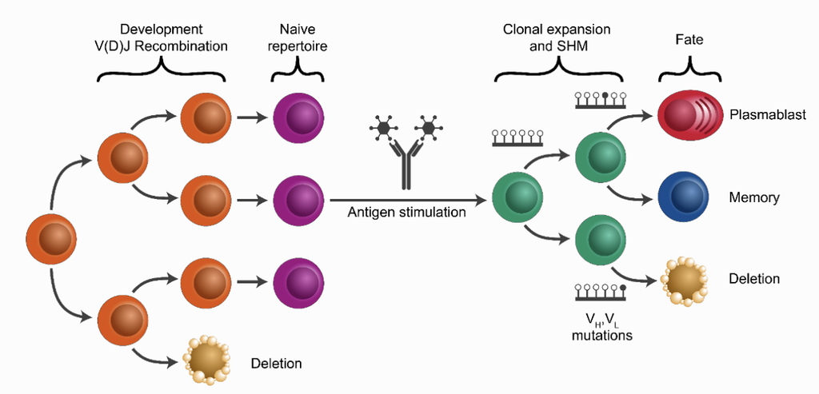

### Example Data

We rely on a subset of Ig sequencing data from Larserson and Vigneault, et al., *PNAS* (2014), which includes sequences from multiple time-points before and after the subject received an immunization.

The example data can be accessed in R by loading the package, and then accessing the dataframe:

```r
library(scoper)

# Look at the top-6 entries
head(scoper::ExampleDb)
```

### Hierarchical Clones

Most current studies uses a more sophisticated definition for clonal relationships. These studies leverage the high diversity of the junction region as a fingerprint to identify each B cell clone. Since it is unlikely that two separate recombination events would lead to identical junctions, sequences with junction regions that are similar enough are determined to share a common B cell ancestor (i.e., be clonally related) rather than to have arisen independently. Hierarchical clustering is a widely used distance-based method for identify clonally related sequences. An implementation of the hierarchical clustering approach is provided via the `hierachicalClones` function.

It is important to determine an appropriate threshold for trimming the hierarchical clustering into B cell clones before using this method. The ideal threshold for separating clonal groups is the value that separates the two modes of the nearest-neighbor distance distribution. The nearest-neighbor distance distribution can be generated by using the `distToNearest` function in the shazam R package. The threshold itself can be found using the`findThreshold` function in the same package. The resulting distribution should be bimodal, with the first mode representing sequences with clonal relatives in the dataset and the second mode representing singletons. For further details regarding inferring an appropriate threshold for the hierarchical clustering method, see the [Distance to Nearest Neighbor](https://shazam.readthedocs.io/en/stable/vignettes/DistToNearest-Vignette) vignette in the shazam package.

- Technical details can be found in: Gupta NT, et al. (2017). Hierarchical clustering can identify B cell clones with high confidence in Ig repertoire sequencing data. *The Journal of Immunology*

Note that identifying clonal groups using `hierachicalClones` is nearly the same as the approach using the `identicalClones` function, with the additional requirement of a distance threshold.

The results `data.frame`, summary plots, and summary table are available. This will show the minimum inter (between) and maximum intra (within) clonal distances along with an effective threshold, which is an explanatory value calculated to represent the cut-off separating the inter and intra clonal distances. The effective threshold may differ from clustering threshold provided as input to hierarchicalClones.

```r
# Define our database as the example database
DB <- scoper::ExampleDb

# Note that distToNearest is from shazam
db1 <- shazam::distToNearest(DB, model="ham", normalize="len",
                             vCallColumn="v_call", jCallColumn = "j_call",
                             sequenceColumn = "junction")

# Calculate threshold
threshold <- shazam::findThreshold(db1$dist_nearest,
                                   method = "gmm", model="gamma-norm",
                                   cutoff="intersect")
# Round off
thr <- round(threshold@threshold, 3)

# Clonal assignment using hierarchical clustering
results <- scoper::hierarchicalClones(DB, method="nt", threshold=thr)
```

```
## Running defineClonesScoper in bulk mode and only keep heavy chains
```

```
## ... identifying heavy chains with getLocus(v_call).
```

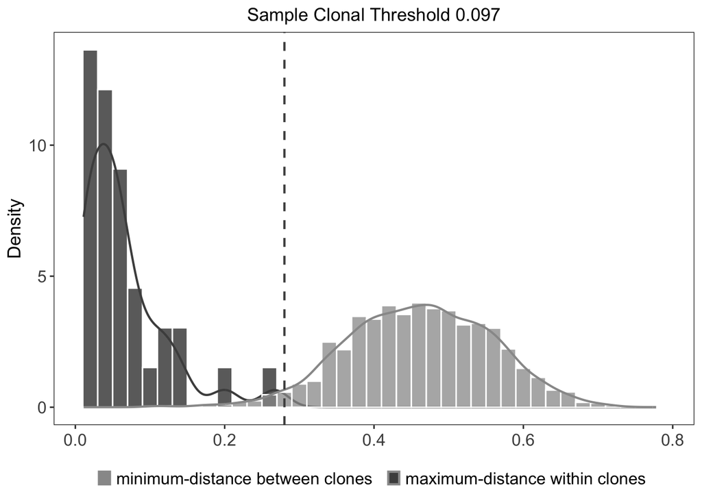

```r
# Graph
scoper::plotCloneSummary(results, binwidth=0.02, title=paste("Sample","Clonal Threshold", thr))
```

```r
# Note that the plotted threshold line is not identical to the calculated threshold line
```

### Clone Identification by Spectral Clustering

While the hierarchical clustering method groups sequences using a fixed distance supervised threshold, the spectral clustering-based model uses an adaptive unsupervised threshold to tune the required level of similarity among sequences in different local neighborhoods. It can be used as an alternative if the nearest-neighbor distance distribution is unimodal, meaning that `findThreshold` wasn’t able to find the threshold at which to cut the hierarchy.

There are two available spectral clustering methods provided by the spectralClones function:

1. `method="novj"`: Infers clonal relationships using an adaptive threshold that indicates the level of similarity among junction sequences in a local neighborhood
2. `method="vj"`: Infers clonal relationships not only based on the junction region homology, but also taking into account the mutation profiles in the V and J segments

It is not mandatory, but a fixed threshold can also be provided to `spectralClone`s (threshold argument) which will enforce an upper-limit cut-off. When specifying the threshold argument, any sequence with distances above the threshold value from all sequences will become a singleton. The threshold can be defined as discussed above using nearest-neighbor distance distribution methods provided in the shazam. If `method="vj"`, the threshold will be applied on the distances calculated combining junction region homology and V/J mutation profiles.

Technical details can be found in:

- Nouri N and Kleinstein SH (2018). A spectral clustering-based method for identifying clones from high-throughput B cell repertoire sequencing data. *Bioinformatics*
- Nouri N and Kleinstein SH (2020). Somatic hypermutation analysis for improved identification of B cell clonal families from next-generation sequencing data, *PLoS Comput Biol*

```r
# Define our database as the example database
DB <- scoper::ExampleDb

# This is the method TH's code used
results <- scoper::spectralClones(DB, method="vj", nproc=16, cdr3=TRUE, iter_max=200, nstart = 50)
```

```
## Running defineClonesScoper in bulk mode and only keep heavy chains
```

```
## ... identifying heavy chains with getLocus(v_call).
```

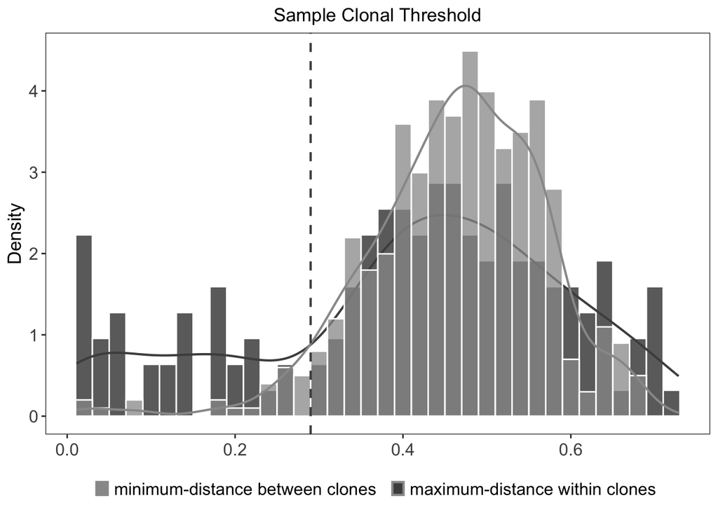

```r
# Plot
scoper::plotCloneSummary(results, binwidth=0.02, title=paste("Sample","Clonal Threshold"))
```

**Note that we can save these data with:**

```r
# Convert results to data.frame
results <- as.data.frame(results)

# Write to YAML or JSON
# the default behavior references the output file string's extension
# airr::write_airr(results, file = "~/file/path")
```

## Part 4) Create Germlines

Note that a helpful reference is here:

- [Introduction to B cell repertoire analysis using the Immcantation framework](https://immcantation.readthedocs.io/en/stable/tutorials/intro-lab.html)

```
DATA_DIR=$(pwd)
#for Sample in {A-S1,B-S3,C-S5,D-S7,E-S9,F-S11,D-S2,A-S4,B-S6,E-S8,F-S10}; do \
#for Sample in {A-S1,B-S3,C-S5,D-S7,E-S9,F-S11}; do \
#for Sample in {SA-S1,SSA-S1} ; do \
#for Sample in {10_S1,11_S2,12_S3,13_S4,14_S5,15_S6,16_S7,17_S8,18_S9,19_S10,20_S11,21_S12,22_S13,23_S14,24_S15,25_S16}; do \
#for Sample in {A2A_S1,L2A_S2,PDA_S3,GblockA_S4,A2G1_S6,L2G1_S7,PD1G1_S8,PD2G1_S9,GblockG1_S10,GloveG1_S11,A2G2_S12,L2G2_S13,PD1G2_S14,GblockG2_S15}; do \
#for Sample in {NegA_S5,A2G1_S6,L2G1_S7}; do \

Sample=GblockA_S4

Sub0=vdj_gapped
Sub1=EVD68/spectralclones
Sub2=EVD68/fullgerm1

IN=data/$Sub1/$Sample-clones.tsv
DB0=data/$Sub1/$Sample-0.tsv
DB1=data/$Sub1/$Sample-1.tsv
DB2=data/$Sub1/$Sample-2.tsv
DB3=data/$Sub1/$Sample-3.tsv
OUT=data/$Sub2/$Sample-fullgerm.tsv

sudo docker run -v $DATA_DIR:/data:z immcantation/suite:devel \
    CreateGermlines.py -d $IN -g full dmask \
        -r data/$Sub0 -o $DB0 --cloned --cf clone_id

sudo docker run -v $DATA_DIR:/data:z immcantation/suite:devel \
    ParseDb.py add -d $DB0  -f sample -u $Sample -o $DB1

sudo docker run -v $DATA_DIR:/data:z immcantation/suite:devel \
    ParseDb.py sort -d $DB1  -f duplicate_count --num --descend -o $DB2

sudo docker run -v $DATA_DIR:/data:z immcantation/suite:devel \
    ParseDb.py index -d $DB2 -o $OUT -f index

#sudo docker run -v $DATA_DIR:/data:z immcantation/suite:devel \
#    ParseDb.py drop -d $DB3 -o $OUT -f sequence_id

rm $(pwd)/$Sub1/$Sample-0.tsv
rm $(pwd)/$Sub1/$Sample-1.tsv
rm $(pwd)/$Sub1/$Sample-2.tsv
rm $(pwd)/$Sub1/$Sample-3.tsv

#done
```

## Part 5) Infer SHM

Note that this part relies heavily on:

- [SHazaM Targeting Vignette](https://shazam.readthedocs.io/en/stable/vignettes/Targeting-Vignette/)

### SHazaM

[SHazaM](https://shazam.readthedocs.io/en/stable/) ([CRAN Documentation](https://cran.r-project.org/web/packages/shazam/shazam.pdf)) is part of the Immcantation analysis framework for Adaptive Immune Receptor Repertoire sequencing (AIRR-seq) and provides tools for advanced analysis of somatic hypermutation (SHM) in immunoglobulin (Ig) sequences. Shazam focuses on the following analysis topics:

1. **Quantification of mutational load** – SHazaM includes methods for determine the rate of observed and expected mutations under various criteria. Mutational profiling criteria include rates under SHM targeting models, mutations specific to CDR and FWR regions, and physicochemical property dependent substitution rates.
2. **Statistical models of SHM targeting patterns** - Models of SHM may be divided into two independent components: (a) a mutability model that defines where mutations occur and (b) a nucleotide substitution model that defines the resulting mutation. Collectively these two components define an SHM targeting model. SHazaM provides empirically derived SHM 5-mer context mutation models for both humans and mice, as well tools to build SHM targeting models from data.
3. **Analysis of selection pressure using BASELINe** - The Bayesian Estimation of Antigen-driven Selection in Ig Sequences (BASELINe) method is a novel method for quantifying antigen-driven selection in high-throughput Ig sequence data. BASELINe uses SHM targeting models can be used to estimate the null distribution of expected mutation frequencies, and provide measures of selection pressure informed by known AID targeting biases.
4. **Model-dependent distance calculations** - SHazaM provides methods to compute evolutionary distances between sequences or set of sequences based on SHM targeting models. This information is particularly useful in understanding and defining clonal relationships.

### SHM Targeting Models

The targeting model is the background likelihood of a particular mutation, based on the surrounding sequence context as well as the mutation itself. The model is inferred from observed mutations in the data. The model can then be transformed into a distance function to compare Ig sequences of a given dataset based on the likelihood of the observed mutations. This is done via the following steps:

1. Infer a substitution model, which is the likelihood of a base mutating to each other base given the microsequence context.
2. Infer a mutability model, which is likelihood of a given base being mutated given the microsequence context and substitution model.
3. Visualize the mutability model to identify hot and cold spots.
4. Calculate a nucleotide distance matrix based on the underlying SHM models.

### Example Data

A small example AIRR Rearrangement database is included in the `alakazam` package. Inferring a targeting model requires the following fields (columns) to be present in the table:

- `sequence_id`
- `sequence_alignment`
- `germline_alignment_d_mask`
- `v_call`

```r
# Load example data
library(shazam)
data(ExampleDb, package="alakazam")

# Subset to IGHG for faster usage demonstration
db <- subset(ExampleDb, c_call == "IGHG")
```

### Infer targeting model(substitution and mutability)

The function for inferring substitution rates (`createSubstitutionMatrix`) counts the number of mutations from a given base to all others occurring in the center position for all 5-mer motifs in the dataset.

The `model` argument of `createSubstitutionMatrix` allows the user to specify whether to count all mutations, or just silent mutations to infer the model. Column names for the sample sequence, germline sequence, and V call can also be passed in as parameters if they differ from Change-O defaults.

Additionally, the `multipleMutation` parameter determines handling of multiple mutations in a single 5-mer: `independent` treats each mutation independently and ignore entirely disregards `5-mers` with multiple mutations.

```r
# Create substitution model using silent mutations
sub_model <- shazam::createSubstitutionMatrix(db, model="s",
                                              sequenceColumn="sequence_alignment",
                                              germlineColumn="germline_alignment_d_mask",
                                              vCallColumn="v_call")
```

The function for inferring a mutability model (`createMutabilityMatrix`) counts the number of mutations in all 5-mer motifs of the dataset, and depends upon the inferred substitution rates. Similar parameters as those available for inferring the substitution rates are available to adjust this function.

```r
# Create mutability model using silent mutations
mut_model <- shazam::createMutabilityMatrix(db, sub_model, model="s",
                                            sequenceColumn="sequence_alignment",
                                            germlineColumn="germline_alignment_d_mask",
                                            vCallColumn="v_call")
```

```r
# Number of silent mutations used for estimating 5-mer mutabilities
mut_model@numMutS
# Number of replacement mutations used for estimating 5-mer mutabilities
mut_model@numMutR
# Mutability and source as a data.frame
head(as.data.frame(mut_model))
```

The inferred substitution and mutability models returned by the above functions only account for unambiguous 5-mers. However, there may be cases in which the user may need the likelihood of a mutation in a 5-mer with ambiguous characters. Each of the above functions has a corresponding function (`extendSubstitutionMatrix` and `extendMutabilityMatrix`) to extend the models to infer 5-mers with Ns by averaging over all corresponding unambiguous 5-mers.

```r
# Extend models to include ambiguous 5-mers
sub_model <- shazam::extendSubstitutionMatrix(sub_model)
mut_model <- shazam::extendMutabilityMatrix(mut_model)
```

These extended substitution and mutability models can be used to create an overall SHM targeting matrix (`createTargetingMatrix`), which is the combined probability of mutability and substitution.

```r
# Create targeting model matrix from substitution and mutability models
tar_matrix <- shazam::createTargetingMatrix(sub_model, mut_model)
```

All of the above steps can be combined by using the single function `createTargetingModel` to infer a `TargetingModel` object directly from the dataset. Again, the numbers of silent and replacement mutations used for estimating the 5-mer mutabilities are also recorded in the `numMutS` and `numMutR` slots respectively.

Additionally, it is generally appropriate to consider the mutations within a clone only once. Consensus sequences for each clone can be generated using the `collapseClones` function.

```r
# Collapse sequences into clonal consensus
clone_db <- shazam::collapseClones(db, cloneColumn="clone_id",
                                   sequenceColumn="sequence_alignment",
                                   germlineColumn="germline_alignment_d_mask",
                                   nproc=1)

# Create targeting model in one step using only silent mutations
# Use consensus sequence input and germline columns
model <- shazam::createTargetingModel(clone_db, model="s", sequenceColumn="clonal_sequence",
                                      germlineColumn="clonal_germline", vCallColumn="v_call")
```

### Targeting Model Visualization

The visualization of a dataset’s underlying SHM mutability model can be used to investigate hot and cold spot motifs. The length of the bars on the plot of mutability rates corresponds to the likelihood of a given base in the given 5-mer being mutated.

The plotting function `plotMutability` has an argument `style` to specify either a hedgehog plot (circlular) or barplot diplay of 5-mer mutability rates. If the mutability for only specific bases is required, this can be specified via the `nucleotides` argument.

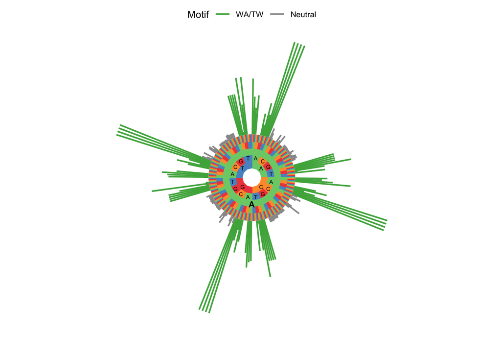

```r
# Generate hedgehog plot of mutability model
shazam::plotMutability(model, nucleotides="A", style="hedgehog")
```

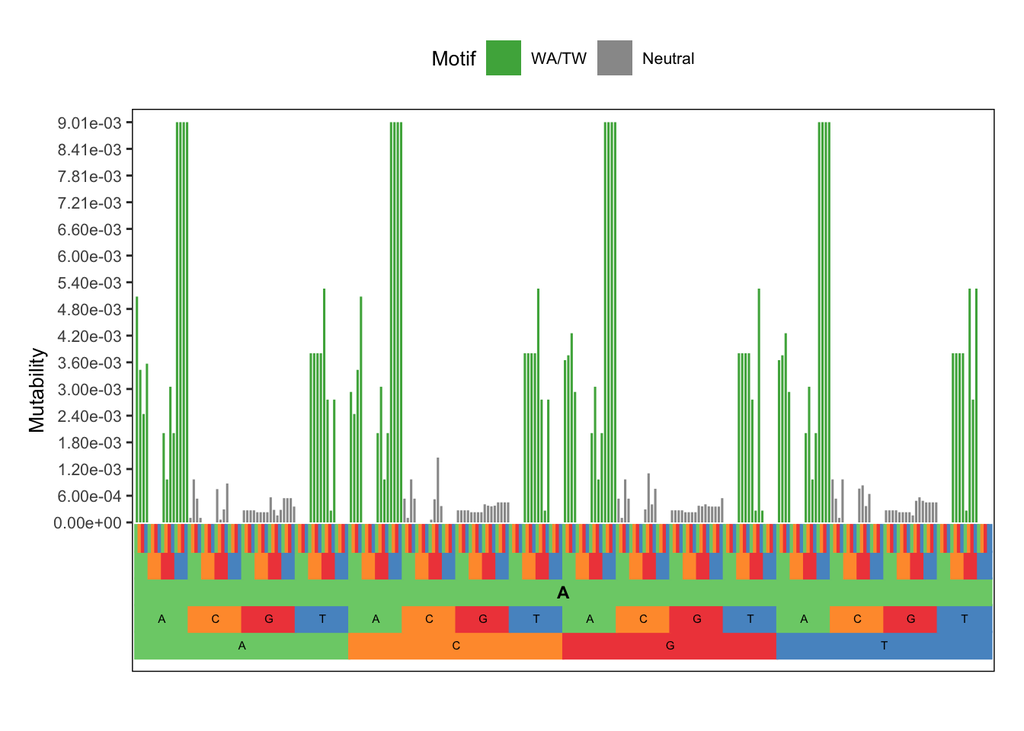

```r
# Generate bar plot of mutability model
shazam::plotMutability(model, nucleotides="A", style="bar")
```

### Calculate targeting distance matrix

In the Change-O pipeline, the `hs5f` cloning method rely on an inferred targeting model. If users wish to use a targeting model inferred from their data to assign distance between sequences for clonal grouping, then the observed SHM targeting rates must be transformed into distances. The `calcTargetingDistance` function returns a matrix of distances between each 5-mer and each corresponding mutation of the center base. This matrix can also be generated and written directly to a file using the function `writeTargetingDistance`.

```r
# Calculate distance matrix
dist <- shazam::calcTargetingDistance(model)
```